# NYPD Shooting Incidents

2024-04-29

### Introduction

This is a brief data analysis on the Shooting Incident dataset provided by NYPD.

Data source: https://data.cityofnewyork.us/api/views/833y-fsy8/rows.csv?accessType=DOWNLOAD

The dataset consists of 28k+ objects with 21 variables. Here is an example data row:

```r
t(head(table, 1))
```

```
##                         1
## INCIDENT_KEY            "244608249"
## OCCUR_DATE              "05/05/2022"
## OCCUR_TIME              "00:10:00"
## BORO                    "MANHATTAN"
## LOC_OF_OCCUR_DESC       "INSIDE"
## PRECINCT                "14"
## JURISDICTION_CODE       "0"
## LOC_CLASSFCTN_DESC      "COMMERCIAL"
## LOCATION_DESC           "VIDEO STORE"
## STATISTICAL_MURDER_FLAG "true"
## PERP_AGE_GROUP          "25-44"
## PERP_SEX                "M"
## PERP_RACE               "BLACK"
## VIC_AGE_GROUP           "25-44"
## VIC_SEX                 "M"
## VIC_RACE                "BLACK"
## X_COORD_CD              "986050"
## Y_COORD_CD              "214231"
## Latitude                "40.75469"
## Longitude               "-73.9935"
## Lon_Lat                 "POINT (-73.9935 40.754692)"
```

Based on observation, the dataset columns can be classified into few groups:

1. Date and Times
2. Locations
3. Personal details of suspects and victims
4. Others numeric values

First we choose the interpretable columns, while excluding columns with most empty values:

```r
table_cleaned <- table %>%
  select(c("OCCUR_DATE","OCCUR_TIME","BORO","PRECINCT",
           "STATISTICAL_MURDER_FLAG","PERP_AGE_GROUP","PERP_SEX","PERP_RACE",
           "VIC_AGE_GROUP","VIC_SEX","VIC_RACE")) %>%
  mutate(OCCUR_DATE = mdy(OCCUR_DATE),
         OCCUR_TIME = hms(OCCUR_TIME),
         Year = year(OCCUR_DATE),
         STATISTICAL_MURDER_FLAG = as.logical(STATISTICAL_MURDER_FLAG)
         )
t(head(table_cleaned, 1))
```

```
##                         1
## OCCUR_DATE              "2022-05-05"
## OCCUR_TIME              "10M 0S"
## BORO                    "MANHATTAN"
## PRECINCT                "14"
## STATISTICAL_MURDER_FLAG "TRUE"
## PERP_AGE_GROUP          "25-44"
## PERP_SEX                "M"
## PERP_RACE               "BLACK"
## VIC_AGE_GROUP           "25-44"
## VIC_SEX                 "M"
## VIC_RACE                "BLACK"
## Year                    "2022"
```

### Count by incidents

Let’s group by year and see the count of shooting incidents per year.

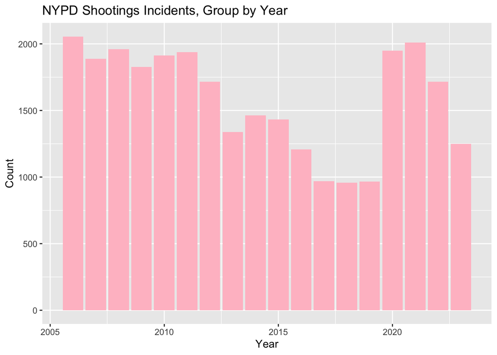

```r
table_cleaned %>%
  ggplot(aes(x = Year)) +
  geom_bar(fill = "pink",show.legend = TRUE) +
  labs(title = "NYPD Shootings Incidents, Group by Year",
       x = "Year",
       y = "Count")
```

From the chart, we can see that shooting count drops declines gradually since 2006, but increases since 2020.

Next we group by different regions.

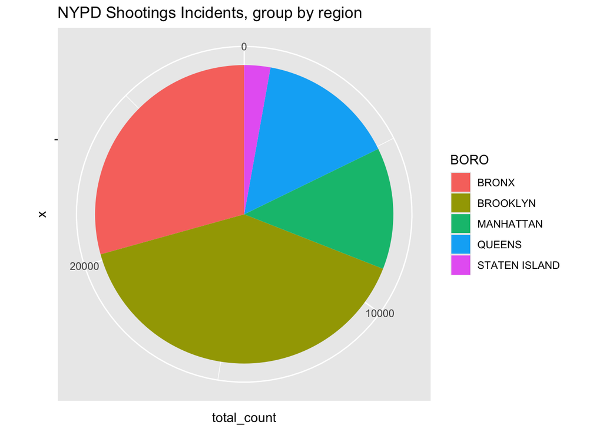

```r
table_boro <- table_cleaned %>%
  group_by(BORO) %>%
  summarize(total_count = n())
table_boro %>%
  ggplot(aes(x="", y=total_count, fill=BORO)) +
  geom_bar(stat="identity", width = 1) +
  coord_polar("y", start=0) +
  labs(title = "NYPD Shootings Incidents, group by region")
```

Based on the pie chart, Brooklyn has the highest number of shooting incidents, followed by Bronx. Staten Island has the least amount.

### Victim analysis

Next, we analyse on the victim identities.

First is the age group:

[figure not shown]

```r
table_victim_age <- table_cleaned %>%
  group_by(VIC_AGE_GROUP) %>%
  summarize(total_count = n())
table_victim_age %>%
  ggplot(aes(x="", y=total_count, fill=VIC_AGE_GROUP)) +
  geom_bar(stat="identity", width = 1) +
  coord_polar("y", start=0) +
  labs(title = "NYPD Shootings Incidents Victims, group by Age Group")
```

The most targeted group is 25-44, followed by 18-24.

Next is the race:

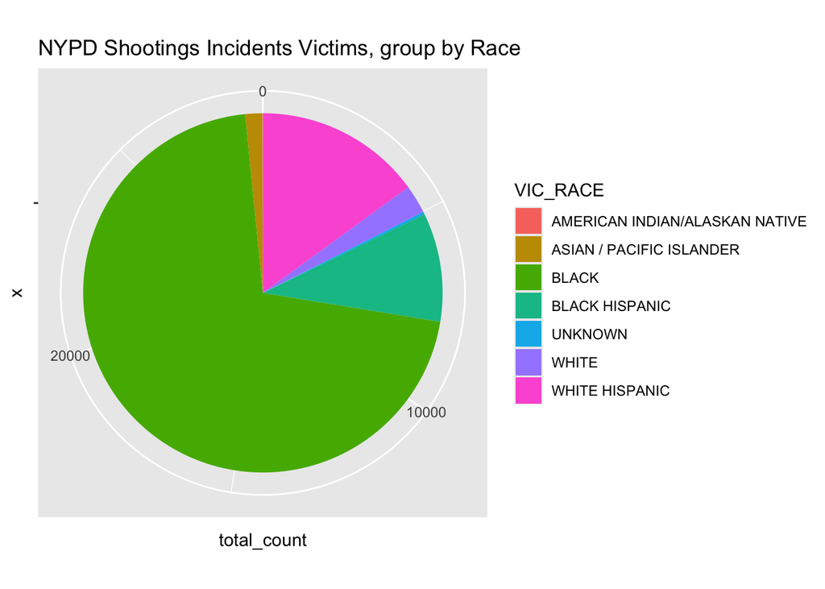

```r
table_victim_race <- table_cleaned %>%
  group_by(VIC_RACE) %>%
  summarize(total_count = n())
table_victim_race %>%
  ggplot(aes(x="", y=total_count, fill=VIC_RACE)) +
  geom_bar(stat="identity", width = 1) +
  coord_polar("y", start=0) +
  labs(title = "NYPD Shootings Incidents Victims, group by Race")
```

Black or Black hispanic people are the most significant group of victims.

### Model

Is the time (hours) of the date directly related to the shooting incidents?

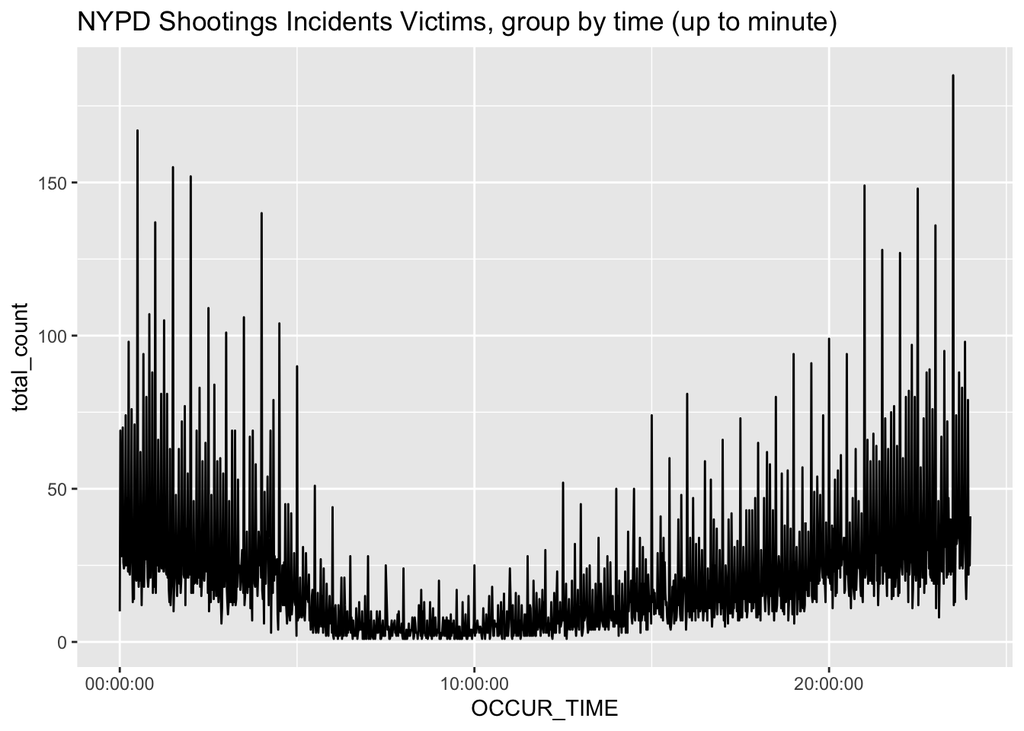

```r
table_shooting_time <- table_cleaned %>%
  group_by(OCCUR_TIME) %>%
  summarize(total_count = n())
table_shooting_time %>%
  ggplot(aes(x=OCCUR_TIME, y=total_count, group=1)) +
  geom_line() +
  scale_x_time() +
  labs(title = "NYPD Shootings Incidents Victims, group by time (up to minute)")
```

From the graph, incidents are more likely to happen during nighttime.

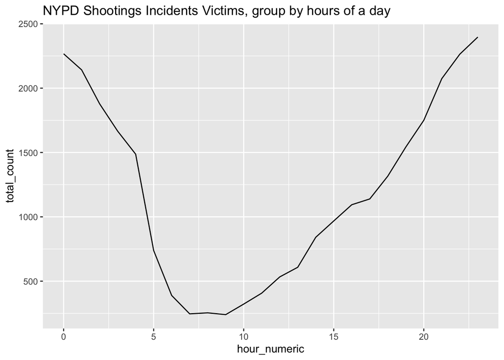

```r
table_shooting_by_hour <- table_cleaned %>%
  mutate(hour_numeric = hour(OCCUR_TIME)) %>%
  group_by(hour_numeric) %>%
  summarize(total_count = n())
table_shooting_by_hour %>%
  ggplot(aes(x=hour_numeric, y=total_count, group=1)) +
  geom_line() +
  labs(title = "NYPD Shootings Incidents Victims, group by hours of a day")
```

The curve indicates the two factors are in quadratic relationship. Create a model between hour and incident count:

```r
mod <- lm(hour_numeric^2 + hour_numeric ~ total_count, data=table_shooting_by_hour)
summary(mod)
```

```
##
## Call:
## lm(formula = hour_numeric^2 + hour_numeric ~ total_count, data = table_shooting_by_hour)
##
## Residuals:
##     Min      1Q  Median      3Q     Max
## -296.39  -83.25   22.36  124.00  242.97
##
## Coefficients:
##             Estimate Std. Error t value Pr(>|t|)
## (Intercept) 75.93610   64.27662   1.181   0.2501
## total_count  0.09725    0.04616   2.106   0.0468 *
## ---
## Signif. codes:  0 '***' 0.001 '**' 0.01 '*' 0.05 '.' 0.1 ' ' 1
##
## Residual standard error: 163.4 on 22 degrees of freedom
## Multiple R-squared:  0.1678, Adjusted R-squared:   0.13
## F-statistic: 4.437 on 1 and 22 DF,  p-value: 0.04679
```

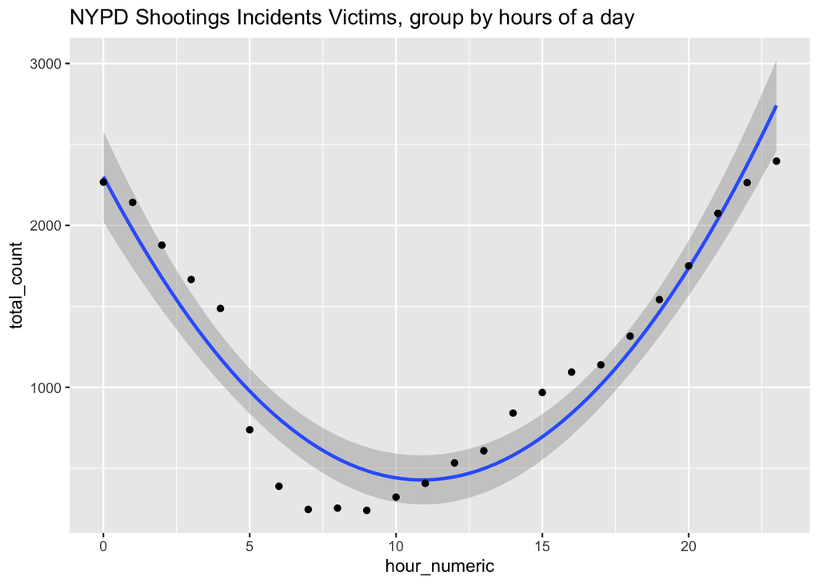

```r
table_shooting_by_hour %>%
  ggplot(aes(x=hour_numeric, y=total_count, group=1)) +
  labs(title = "NYPD Shootings Incidents Victims, group by hours of a day") +
  stat_smooth(method="lm", formula = y ~ I(x^2) + x) +
  geom_point()
```